# RepData_PeerAssesment2

Valerio Vaccaro

21 September 2015

# Severe weather events in the United States: analisys on public health and the economy impacts.

This work address the analisys of sever weather events consequences (fatalities, injuries, and property damage) on public healt and economic problems based on events recorded in the the U.S. National Oceanic and Atmospheric Administration’s (NOAA) storm database. This database tracks characteristics of major storms and weather events in the United States, including when and where they occur, as well as estimates of any fatalities, injuries, and property damage from 1950 to November 2011.

We want answer to the following questions:

- Across the United States, which types of events are most harmfull with resprect to population health?
- Across the United States, which types of events have the greatest economic consequences?

As we will see in this document the Tornadoes on public healt and Floods, respect to ecomomical impacts, are the most critical weather events.

## Dowload dataset

The dataset is located at [this address](http://d396qusza40orc.cloudfront.net/repdata%2Fdata%2FStormData.csv.bz2) and tracks characteristics of major storms and weather events in the United States from 1950 to November 2011.

```r
library(plyr)
library(dplyr)
```

```r
library(ggplot2)
library(gridExtra)

# Download the file if it's not directly available
if (!file.exists("./StormData.csv.bz2")) {
    download.file("http://d396qusza40orc.cloudfront.net/repdata%2Fdata%2FStormData.csv.bz2", destfile = "./StormData.csv.bz2") }

# Import zipped csv file in R
StormData <- read.csv("./StormData.csv.bz2")
#, nrow=200000
```

The complete dataset contains 902297 observations with 37 columns each one.

```r
str(StormData)
```

```
## 'data.frame':    902297 obs. of  37 variables:
##  $ STATE__   : num  1 1 1 1 1 1 1 1 1 1 ...
##  $ BGN_DATE  : Factor w/ 16335 levels "1/1/1966 0:00:00",..: 6523 6523 4242 11116 2224 2224 2260 383 3980 3980 ...
##  $ BGN_TIME  : Factor w/ 3608 levels "00:00:00 AM",..: 272 287 2705 1683 2584 3186 242 1683 3186 3186 ...
##  $ TIME_ZONE : Factor w/ 22 levels "ADT","AKS","AST",..: 7 7 7 7 7 7 7 7 7 7 ...
##  $ COUNTY    : num  97 3 57 89 43 77 9 123 125 57 ...
##  $ COUNTYNAME: Factor w/ 29601 levels "","5NM E OF MACKINAC BRIDGE TO PRESQUE ISLE LT MI",..: 13513 1873 4598 10592 4372 10094 1973 23873 24418 4598 ...
##  $ STATE     : Factor w/ 72 levels "AK","AL","AM",..: 2 2 2 2 2 2 2 2 2 2 ...
##  $ EVTYPE    : Factor w/ 985 levels "   HIGH SURF ADVISORY",..: 834 834 834 834 834 834 834 834 834 834 ...
##  $ BGN_RANGE : num  0 0 0 0 0 0 0 0 0 0 ...
##  $ BGN_AZI   : Factor w/ 35 levels "","  N"," NW",..: 1 1 1 1 1 1 1 1 1 1 ...
##  $ BGN_LOCATI: Factor w/ 54429 levels ""," Christiansburg",..: 1 1 1 1 1 1 1 1 1 1 ...
##  $ END_DATE  : Factor w/ 6663 levels "","1/1/1993 0:00:00",..: 1 1 1 1 1 1 1 1 1 1 ...
##  $ END_TIME  : Factor w/ 3647 levels ""," 0900CST",..: 1 1 1 1 1 1 1 1 1 1 ...
##  $ COUNTY_END: num  0 0 0 0 0 0 0 0 0 0 ...
```

[output cut: 23 more lines]

## Data Processing

In the first step we will select only the columns useful for this analisys:

- EVTYPE, event type
- FATALITIES, number of deaths
- INJURES, number of injures
- PROPDMG, values of property damages in dollars
- PROPDMGEXP, exponent of PROPDMG
- CROPDMG, values of crop damages in dollars
- CROPDMGEXP, exponent for CROPDMG

```r
StormData <- StormData[, c("EVTYPE", "FATALITIES", "INJURIES", "PROPDMG", "PROPDMGEXP", "CROPDMG", "CROPDMGEXP") ]
```

This dataset contains 902297 observations but actually there are only 7 columns.

The damages amount is reported in dollars and splitted in two different columns, value and exponent Kind of content in the exponent columns are:

- NA (no exponent) has to be translate as 0 exponent (10^0=1)
- + or - or ? has to be translate as 0 exponent (10^0=1)
- h or H char means hundrends so exponent hast to be 2 (10^2=100)
- k or K char (kilo) means thousands so exponent hast to be 3 (10^3=1000)
- m or M char (mega) meand millions so exponent hast to be 6 (10^6=1000000)
- b or B char meand billions so exponent hast to be 9 (10^9=1000000000)

```r
# Convert in char array
StormData$PROPDMGEXP <- as.character(StormData$PROPDMGEXP)
StormData$CROPDMGEXP <- as.character(StormData$CROPDMGEXP)
# If NA exponent is 0
StormData$PROPDMGEXP[is.na(StormData$PROPDMGEXP)] <- 0
StormData$CROPDMGEXP[is.na(StormData$CROPDMGEXP)] <- 0
# If -,+,? exponent is 0
StormData$PROPDMGEXP <- gsub("\\-|\\+|\\?", "0", StormData$PROPDMGEXP)
StormData$CROPDMGEXP <- gsub("\\-|\\+|\\?", "0", StormData$CROPDMGEXP)
# If H exponent is 2
StormData$PROPDMGEXP <- gsub("h|H", "2", StormData$PROPDMGEXP)
StormData$CROPDMGEXP <- gsub("h|H", "2", StormData$CROPDMGEXP)
# If K exponent is 3
StormData$PROPDMGEXP <- gsub("k|K", "3", StormData$PROPDMGEXP)
StormData$CROPDMGEXP <- gsub("k|K", "3", StormData$CROPDMGEXP)
# If M exponent is 6
StormData$PROPDMGEXP <- gsub("m|M", "6", StormData$PROPDMGEXP)
StormData$CROPDMGEXP <- gsub("m|M", "6", StormData$CROPDMGEXP)
# If B exponent is 9
StormData$PROPDMGEXP <- gsub("b|B", "9", StormData$PROPDMGEXP)
StormData$CROPDMGEXP <- gsub("b|B", "9", StormData$CROPDMGEXP)
# convert as numeric
StormData$PROPDMGEXP <- as.numeric(StormData$PROPDMGEXP)
StormData$CROPDMGEXP <- as.numeric(StormData$CROPDMGEXP)
# If NA exponent is 0
StormData$PROPDMGEXP[is.na(StormData$PROPDMGEXP)] <- 0
StormData$CROPDMGEXP[is.na(StormData$CROPDMGEXP)] <- 0
```

With numerical exponent we can recalculate damages for properties and crop fields. The variable total damages contain the sum of both damages.

```r
#calc damages
StormDataCorrected <- mutate(StormData, PROPERTY_DAMAGE = PROPDMG * 10^PROPDMGEXP, CROPS_DAMAGE = CROPDMG * 10^CROPDMGEXP, TOTAL_DAMAGE = PROPERTY_DAMAGE +  CROPS_DAMAGE)
```

We can summarize the complete dataset by event type and calculates:

- total fatalities for each event type
- total injuries for each event type
- total property damages for each event type
- total crop damages for each event type.

```r
# summary by EVTYPE
event_summary <- group_by(StormDataCorrected, EVTYPE)
# calculate summaries
StormSummary <- summarize(event_summary,
        total_fatalities = sum(FATALITIES, na.rm = TRUE),
        total_injuries = sum(INJURIES, na.rm = TRUE),
        total_propdmg = sum(PROPERTY_DAMAGE, na.rm = TRUE),
        total_cropdmg = sum(CROPS_DAMAGE, na.rm = TRUE),
        total_damages = sum (TOTAL_DAMAGE, na.rm = TRUE)     )
# print structure
str(StormSummary)
```

```
## Classes 'tbl_df', 'tbl' and 'data.frame':    985 obs. of  6 variables:
##  $ EVTYPE          : Factor w/ 985 levels "   HIGH SURF ADVISORY",..: 1 2 3 4 5 6 7 8 9 10 ...
##  $ total_fatalities: num  0 0 0 0 0 0 0 0 0 0 ...
##  $ total_injuries  : num  0 0 0 0 0 0 0 0 0 0 ...
##  $ total_propdmg   : num  200000 0 50000 0 8100000 8000 0 0 5000 0 ...
##  $ total_cropdmg   : num  0 0 0 0 0 0 0 0 0 0 ...
##  $ total_damages   : num  200000 0 50000 0 8100000 8000 0 0 5000 0 ...
##  - attr(*, "drop")= logi TRUE
```

## Results

Now we can finally anwer to questions about consequences of several weather events based on summarized datasets.

### Across the United States, which types of events are most harmful with respect to population health?

We can order the dataset regardings fatalities and injuries and plot the first 10 values.

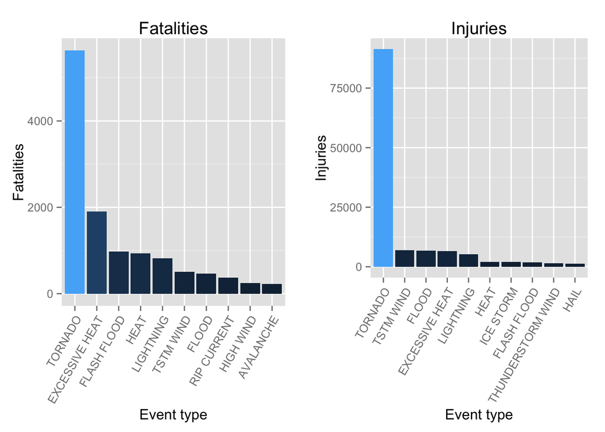

```r
# Order by fatalities
StormSummary_order_total_fatalities <- StormSummary[order(StormSummary$total_fatalities, decreasing = T), ][1:10, ]
# Plot fatalities
plot_fatalities <- ggplot(StormSummary_order_total_fatalities, aes(x=reorder(EVTYPE, -total_fatalities), y=total_fatalities, fill=total_fatalities)) +
        geom_bar(stat = "identity") +
        ylab("Fatalities") +
        xlab("Event type") +
        ggtitle ("Fatalities") +
        theme(axis.text.x = element_text(angle = 60, hjust = 1)) +
        theme(legend.position="none")

# Order by injuries
StormSummary_order_total_injuries <- StormSummary[order(StormSummary$total_injuries, decreasing = T), ][1:10, ]
# Plot injuries
plot_injuries <- ggplot(StormSummary_order_total_injuries, aes(x=reorder(EVTYPE, -total_injuries), y=total_injuries, fill=total_injuries)) +
        geom_bar(stat = "identity") +
        ylab("Injuries") +
        xlab("Event type") +
        ggtitle ("Injuries") +
        theme(axis.text.x = element_text(angle = 60, hjust = 1)) +
        theme(legend.position="none")

grid.arrange(plot_fatalities, plot_injuries, ncol=2)
```

The most harmful events for population healts are tornadoes that are responsible for a big number of fatalities and injuries, excessive heat and floods can cause a big number of fatalities also.

### Across the United States, which types of events have the greatest economic consequences?

We can order the dataset using properties and crop damages columns then print the first 10 values for each set.

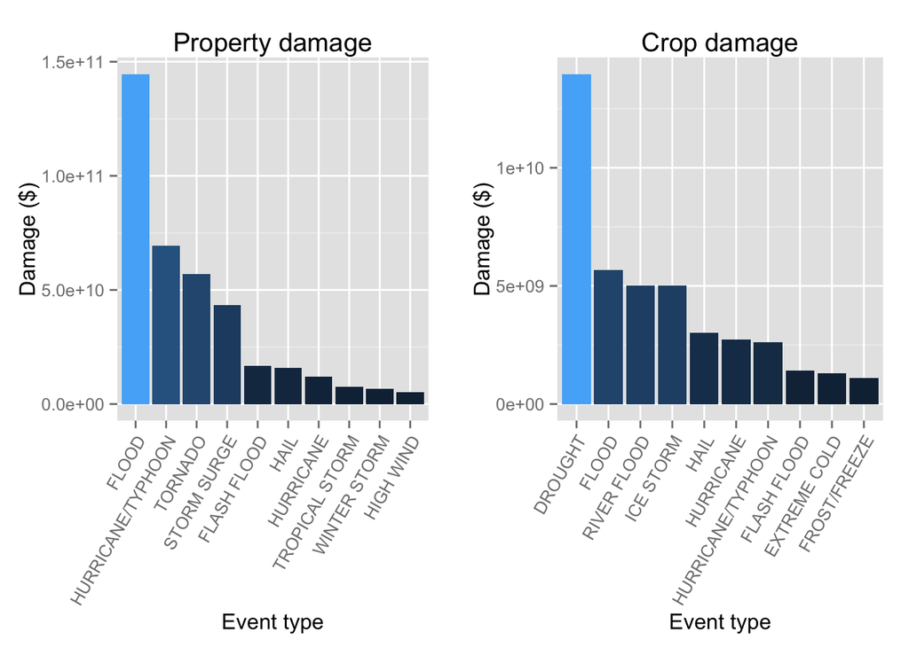

```r
# Order by property damages
StormSummary_order_propdmg <- StormSummary[order(StormSummary$total_propdmg, decreasing = T), ][1:10, ]
# Plot damages
plot_propdmg <- ggplot(StormSummary_order_propdmg, aes(x=reorder(EVTYPE, -total_propdmg), y=total_propdmg, fill=total_propdmg)) +
        geom_bar(stat="identity") +
        ggtitle("Property damage") +
        xlab("Event type") +
        ylab("Damage ($)") +
        theme(axis.text.x = element_text(angle = 60, hjust = 1)) +
        theme(legend.position="none")

# Order by crop damages
StormSummary_order_propdmg <- StormSummary[order(StormSummary$total_cropdmg, decreasing = T), ][1:10, ]
# Plot damages
plot_cropdmg <- ggplot(StormSummary_order_propdmg, aes(x=reorder(EVTYPE, -total_cropdmg), y=total_cropdmg, fill=total_cropdmg)) +
        geom_bar(stat="identity") +
        ggtitle("Crop damage") +
        xlab("Event type") +
        ylab("Damage ($)") +
        theme(axis.text.x = element_text(angle = 60, hjust = 1)) +
        theme(legend.position="none")

grid.arrange(plot_propdmg, plot_cropdmg, ncol = 2)
```

The biggest economic consequences for property damages are floods, hurricanes and tornadoes; on the other hand for crop damages droughts and floods are the most dangerouse weather events.

```r
# Order by total damages
StormSummary_order_damages <- StormSummary[order(StormSummary$total_damages, decreasing = T), c("EVTYPE","total_damages") ][1:10, ]
StormSummary_order_damages
```

```
## Source: local data frame [10 x 2]
##
##               EVTYPE total_damages
## 1              FLOOD  150319678257
## 2  HURRICANE/TYPHOON   71913712800
## 3            TORNADO   57362333946
## 4        STORM SURGE   43323541000
## 5               HAIL   18761221986
## 6        FLASH FLOOD   18243991078
## 7            DROUGHT   15018672000
## 8          HURRICANE   14610229010
## 9        RIVER FLOOD   10148404500
## 10         ICE STORM    8967041360
```

If we sum property and crop damages we obtain total damages in witch the biggest economic consequences are made by the same events for property analisys (floods, hurricanes and tornadoes).